# STIN300: Mandatory Assignement

Severin Langberg

1/21/2019

```r
knitr::opts_chunk$set(echo = TRUE)

library(gtools)
library(stringr)
library(tidyverse)

set.seed(2019)
```

## Part 1

Functions for reading and formatting data:

```r
ReadFasta <- function(path_to_file) {
  # Read and format Neuraminidase data.
  raw.lines <- readLines(path_to_file)
  header.idx <- which(str_detect(raw.lines, '>'))
  fasta.table <- tibble(
    Header = str_remove(raw.lines[header.idx], '^>'),
    Sequence = rep('', length(header.idx))
  )
  # Add a final value to the index vector.
  header.idx <- c(header.idx, length(raw.lines) + 1)
  for(i in 1:(length(header.idx) - 1)) {
    dna.seq <- raw.lines[(header.idx[i] + 1):(header.idx[i + 1] - 1)]
    # Join multiple strings into a single string combined with `collapse`.
    fasta.table$Sequence[i] <- str_c(dna.seq, collapse="")
  }
  return(fasta.table)
}


FormatFasta <- function(fasta.table, add_serotype=T) {
  # Format the Serotype feature.
  if (add_serotype) {
    fasta.table <- (
      fasta.table
      %>% mutate(
        Serotype=str_extract(
          fasta.table$Header, pattern='H[0-9]{1,2}N[0-9]{1,2}'
        ),
        H.type=str_extract(fasta.table$Header, pattern='H[0-9]{1,2}'),
        N.type=str_extract(fasta.table$Header, pattern='N[0-9]{1,2}')
      )
      %>% drop_na(Var=Serotype)
    )
  }
  return (fasta.table)
}
```

Read the *Neuraminidase.fasta* data file into R, and format the *Serotype* feature.

Plotting the frequency of each N-type in the data set.

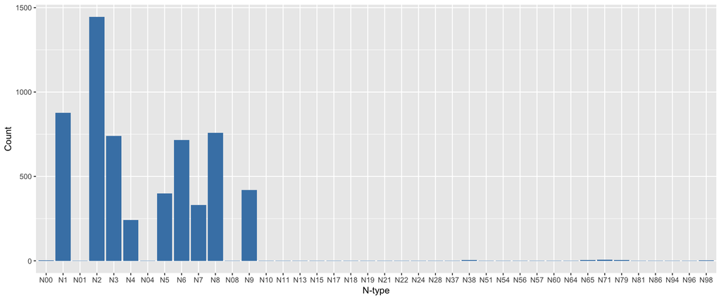

Plotting the frequency of each H-type and N-type pair in assessing how often a given H-type combine with a specific N-types.

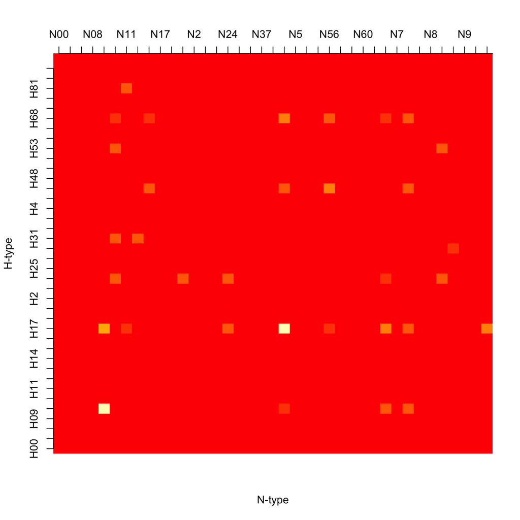

## Part 2

Given the function `elmers` to generate all possible L-mers in sorted order, a function counting L-mer occurances given a single DNA sequence and an integer value L is given in `elmerCounts`:

```r
elmerCounts <- function(seq.str, elmers, L) {
  # Count the number of L-mers extracted from a character
  # sequence.
  lmer.counts <- numeric(length(elmers))
  # The total number of sequence divisions.
  n.splits <- str_length(seq.str) - L + 1
  for (i in 1:n.splits) {
    # Extract the L-mer sequence and determine its position
    # relative to the complete L-mer space.
    lmer <- substr(seq.str, start=i, stop=i + L - 1)
    idx <- match(lmer, all.lmers)
    # Update the count for each encountered L-mer.
    lmer.counts[idx] <- lmer.counts[idx] + 1
  }
  return(lmer.counts)
}
```

Generating a 2-mer count matrix scaled to unit row sums with setup

```r
L <- 2
n.seqs <- length(fasta.table$Sequence)
all.lmers <- elmers(L=L, iter=1, alphabet=c('A', 'C', 'G', 'T'))
M <- matrix(0, nrow=n.seqs, ncol=length(all.lmers))
colnames(M) <- all.lmers
```

Collect a DNA sequence from the data set, create a vector with counts of each encountered L-mer and store the result in the count matrix.

```r
for (i in 1:n.seqs) {
  lmer.counts <- elmerCounts(fasta.table$Sequence[i], all.lmers, L=L)
  M[i, ] <- lmer.counts
}
```

Scale rows to unit length, and converting the 2-mer count matrix to a table and binding it to the *Neuraminidase.fasta* table, and extracting a subset containing only the cases for N-types N1, N3 and N6.

```r
M <- as.data.frame(M / rowSums(M, na.rm=T))
fasta.ext <- bind_cols(fasta.table, M)
```

Building an LDA model from the selected with N-types as response variable, and plotting the transformed features in the linear discriminants space, colouring the N-types.

```r
fasta.sub <- (
  fasta.ext[which(fasta.ext$N.type %in% c('N1', 'N3', 'N6')), ]
  %>% subset(select=-c(Header, Sequence, Serotype))
)
lda.model <- MASS::lda(N.type ~ ., data=fasta.sub)
```

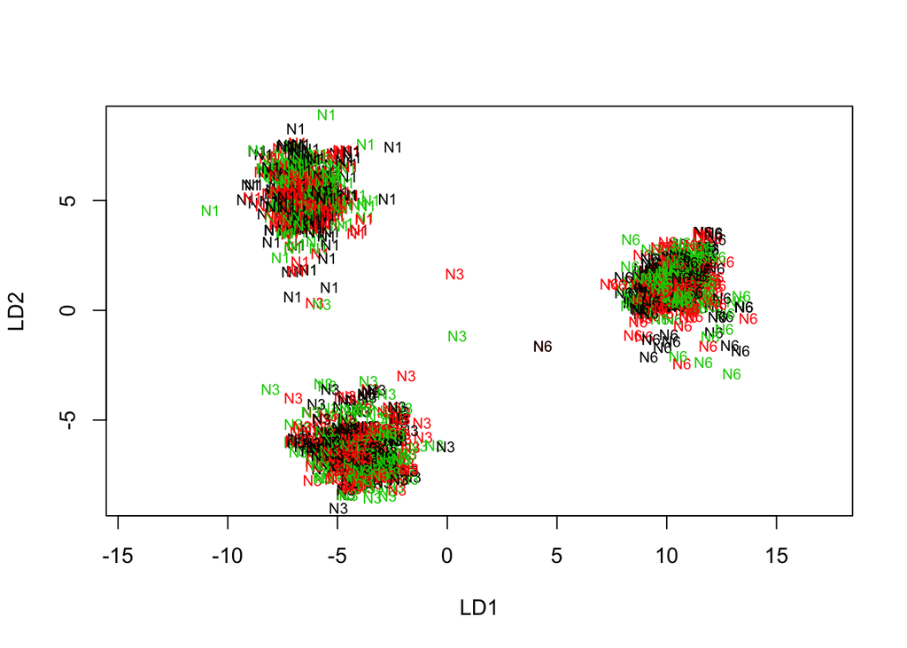

```r
plot(
  lda.model, col=seq(1, 100, 1)[unique(factor(fasta.sub$N.type))]
)
```

## Part 3

Implementing the distance function

```r
log2.dist <- function(p, Q) {
  # Inputs a vector `p` and a matrix `Q`. Returns a vector
  # of distances from p to each row in Q.
  nrows <- nrow(Q)
  pQ.dist <- numeric(nrows)
  for (i in 1:nrows) {
    # Calculate the distance between vector p and the vector
    # being a row in Q.
    pq.dist <- sum(abs(log2(p / Q[i, ])))
    pQ.dist[i] <- pq.dist
  }
 return(pQ.dist)
}
```

and the the k-NN algorithm.

```r
knn_predict <- function(X.train, X.test, y.train, k=3) {
  # Implementaiton of the k-nearest neighbor classification
  # algorithm.
  n.test <- nrow(X.test)
  indicators = numeric(n.test)
  for (i in 1:n.test) {
    # Compute the distance vector.
    test.dist <- log2.dist(X.test[i, ], X.train)
    # Select the k closest neighbors.
    top.k.idx <- order(test.dist, decreasing=FALSE)[1:k]
    # Map the k smallest dinstances to response labels.
    indicators[i] <- major_vote(y.train[top.k.idx])

  }
  return(indicators)
}
```

The majority voting scheme for prediction and model performance score are defined as

```r
major_vote <- function(x) {
  return(names(sort(table(x), decreasing=T)[1]))
}

knn_score <- function(y_true, y_pred) {
  error = length(setdiff(y_true, y_pred)) / length(y_true)
  return(1- error)
}
```

Classifying N-types from the neuraminidase data with $k \in [1, 3, 5]$ with 100-fold CV of performance.

```r
k.neigh <- c(1, 3, 5)
n.folds <- 100

X <- (
  fasta.ext
  %>% subset(select=-c(Header, Sequence, Serotype, H.type, N.type))
  %>% as.matrix()
)
y <- fasta.ext %>% subset(select=c(N.type)) %>% as.matrix()

# Sample test data indices without replacement.
fold_idx <- sample(rep(1:n.folds, length.out=nrow(X)))

avg.scores <- numeric(length(k.neigh))
for (n in 1:length(k.neigh)) {

  scores <- numeric(n.folds)
  for (j in 1:n.folds) {
    # Collect the indices of samples in each fold.
    test_idx <- which(fold_idx == j)

    X.test <- X[test_idx, ]
    X.train <- X[-test_idx, ]

    y.test <- y[test_idx]
    y.train <- y[-test_idx]

    y.pred <- knn_predict(X.train, X.test, y.train, k=k.neigh[n])
    scores[j] <- knn_score(y.test, y.pred)
  }
  avg.scores[n] <- mean(scores)
}
```

Plot the averaged 100-fold CV scores for each configuration of $k$.

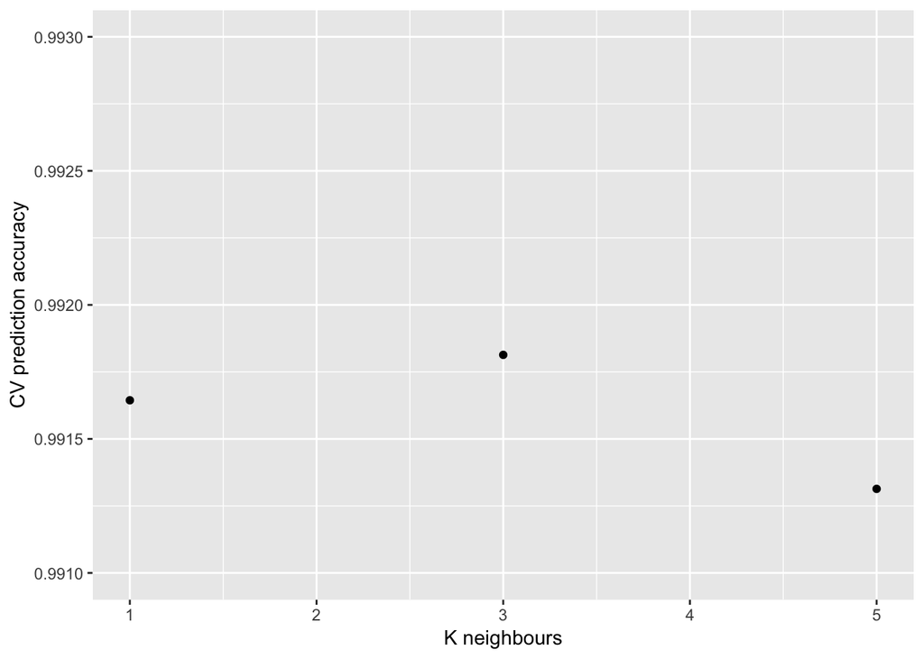

```r
cv.results <- bind_cols(
  data.frame(Scores=avg.scores),
  data.frame(K=k.neigh)
)
ggplot(as.data.frame(cv.results)) + geom_point(aes(x=K, y=Scores)) + labs(x='K neighbours', y='CV prediction accuracy') + ylim(0.991, 0.993)
```